# Fit MOSM GP to 2-band synthetic example

This notebook contains the workflow for:

- loading groundtruth 2-band (MOGP) time-series,
- fitting a multicomponent MOSM GP model,
- drawing posterior predictive samples,
- visualising the posteriors .

```r
library(here)
library(dplyr)
library(tidyr)
library(ggplot2)
library(cmdstanr)
library(posterior)
library(bayesplot)
library(readr)
library(glue)
library(jsonlite)

register_knitr_engine(override = FALSE)

theme_set(theme_bw())
color_scheme_set("viridis")

source(here("mogp-utils.R"))

filename_stub <- "D2-Q3-seed2312-n300-mnar0.3-noise0.5"

EXECUTE_SAMPLING <- FALSE

N_CHAINS <- 4
N_WARMUP <- 500
N_SAMPLES <- 500

# Function estimates the mode of a sample
estimate_mode <- function(x) {
  d <- density(x, n = 2^6)
  d$x[which.max(d$y)]
}
```

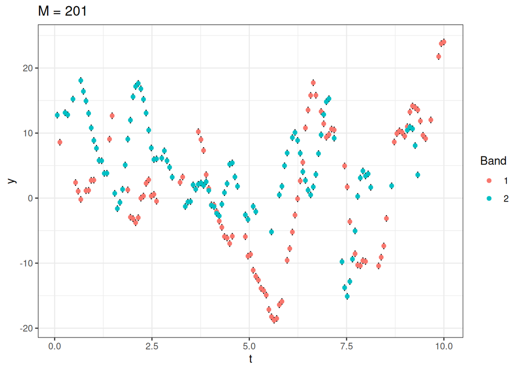

```r
input_df <- read_csv(
  here("data", glue("{filename_stub}-sim.csv")),
  col_types = "dddf",
  show_col_types = FALSE)

input_params <- read_json(
  here("data", glue("{filename_stub}-param.json")),
  simplifyVector = TRUE)

input_df |>
  ggplot() +
  aes(x = t, y = y, colour = factor(d)) +
  geom_linerange(aes(ymax = y + y_se, ymin = y - y_se), colour = "black") +
  geom_point() +
  labs(colour = "Band", title = glue("M = {NROW(input_df)}"))
```

```r
input_params
```

```
$seed
[1] 2312

$w
     [,1] [,2]
[1,] 1.66 2.05
[2,] 2.20 1.49
[3,] 1.90 1.76

$mu
     [,1] [,2]
[1,] 0.07 0.47
[2,] 1.10 3.11
[3,] 1.12 0.12

$Sigma
        [,1]  [,2]
[1,]  0.4356  0.31
[2,] 10.4976 10.83
[3,] 13.6161 14.02

$theta
     [,1] [,2]
[1,]    0 2.32
[2,]    0 0.83
[3,]    0 0.10

$phi
     [,1]  [,2]
[1,]    0 -1.29
[2,]    0  0.33
[3,]    0  1.36
```

# Model Fitting

```r
stan_model <- cmdstan_model(here("stan", "mosmgp-D2-Q.stan"))
```

## Sampling

```r
D <- 2
Q <- 3

band1_df <- filter(input_df, d == 1)
band1_mean <- mean(band1_df$y)
band1_sd <- sd(band1_df$y)

band2_df <- filter(input_df, d == 2)
band2_mean <- mean(band2_df$y)
band2_sd <- sd(band2_df$y)

ell_min <- median(  diff( sort(input_df$t) )  )
ell_max <- diff(range(input_df$t))
ell_loc <- log(sqrt(ell_min * ell_max)) # for log-normal prior

data_list <- list(
  Q = Q,
  N1 = length(band1_df$t),
  N2 = length(band2_df$t),
  t1 = band1_df$t,
  t2 = band2_df$t,
  y1 = (band1_df$y - band1_mean)/band1_sd, # standardised
  y2 = (band2_df$y - band2_mean)/band2_sd,
  y1_se = band1_df$y_se/band1_sd,
  y2_se = band2_df$y_se/band2_sd,
  ell_min = ell_min,
  ell_max = ell_max,
  ell_loc = ell_loc,
  ell_scale = 1,
  v_scale = 1, # data has been standardised
  mu_scale = 3
)
```

```r
ell_min
```

```
[1] 0.06711409
```

```r
ell_max
```

```
[1] 9.932886
```

```r
ell_loc
```

```
[1] -0.2027551
```

### Priors

$$w^2 = \frac{v}{\sqrt{2 \pi \Sigma}}, \quad \Sigma = \frac{1}{\ell^2}$$

$$v \sim \mathcal{N}_+(0, v_\textrm{scale}), \quad \mu \sim \mathcal{N}_+(0, \mu_\textrm{scale}), \quad \ell \sim \mathrm{lognormal}(\ell_\textrm{loc}, \ell_\textrm{scale}), \quad \theta_2 \sim \mathcal{N}(0, 1), \quad \phi_2 \sim \mathrm{U}[-\pi, \pi]$$

$$v_\textrm{scale} = 1, \quad \mu_\textrm{scale} = 3, \quad \ell_\textrm{loc} = \log(\sqrt{\ell_\textrm{min}\times \ell_\textrm{max}}, \quad \ell_\textrm{scale} = 1,$$

```r
format(start_time <- Sys.time())
```

```
[1] "2026-10-22 23:13:43"
```

```r
if (EXECUTE_SAMPLING) {
  init_fun <- function() {
    list(
      mu1 = c(0.79, 2.72, 0.2) + rnorm(Q, 0, 0.1),
      mu2 = c(0.93, 2.81, 0.19) + rnorm(Q, 0, 0.1)
    )
  }

  output <- stan_model$sample(
    data = data_list,
    #init = init_fun,
    chains = N_CHAINS,
    parallel_chains = N_CHAINS,
    iter_warmup = N_WARMUP,
    iter_sampling = N_SAMPLES,
    refresh = 500,
    show_exceptions = FALSE,
    show_messages = TRUE
  )

  output$save_object(
    here("RDS", glue("{filename_stub}_mosmgp-D{D}-Q{Q}.RDS")))

} else {
  output <- readRDS(
    here("RDS", glue("{filename_stub}_mosmgp-D{D}-Q{Q}.RDS")))
}

format(finish_time <- Sys.time())
```

```
[1] "2026-10-22 23:13:43"
```

```r
difftime(finish_time, start_time)
```

```
Time difference of 0.01040316 secs
```

# Results

```r
vars <- c("w", "mu", "Sigma", "theta", "phi")
output$summary(variables = vars,
               posterior::default_convergence_measures())
```

```
# A tibble: 30 × 4
   variable  rhat ess_bulk ess_tail
   <chr>    <dbl>    <dbl>    <dbl>
 1 w[1,1]    1.01     462.     511.
 2 w[2,1]    1.01     521.     794.
 3 w[3,1]    1.01     378.     617.
 4 w[1,2]    1.01     722.     510.
 5 w[2,2]    1.00     955.     873.
 6 w[3,2]    1.01     895.     788.
 7 mu[1,1]   1.00    1072.     829.
 8 mu[2,1]   1.00    1028.    1295.
 9 mu[3,1]   1.00     569.     825.
10 mu[1,2]   1.01     659.     798.
# ℹ 20 more rows
```

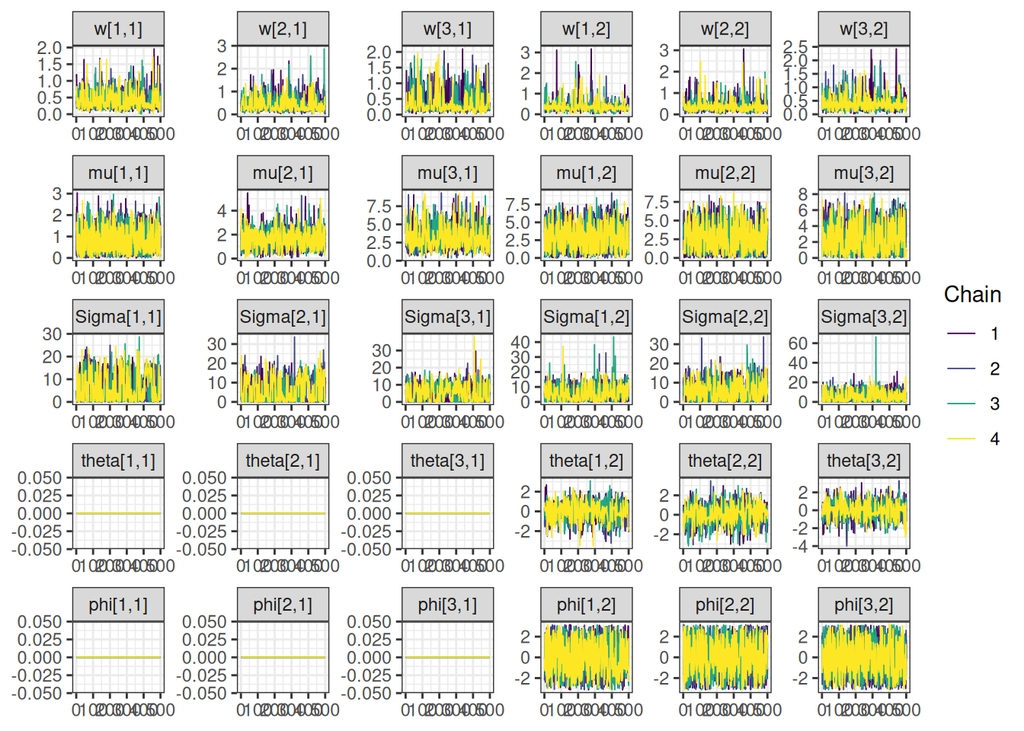

```r
mcmc_trace(output$draws(vars))
```

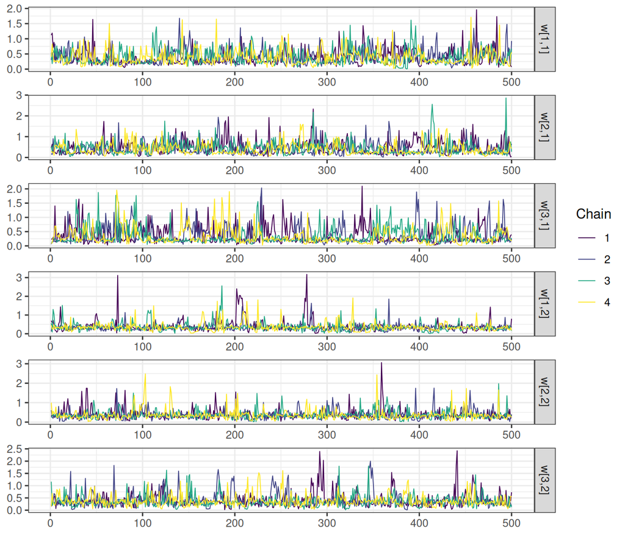

```r
mcmc_trace(output$draws(vars), pars = vars(starts_with("w")),
           facet_args = list(ncol = 1, strip.position = "right"))
```

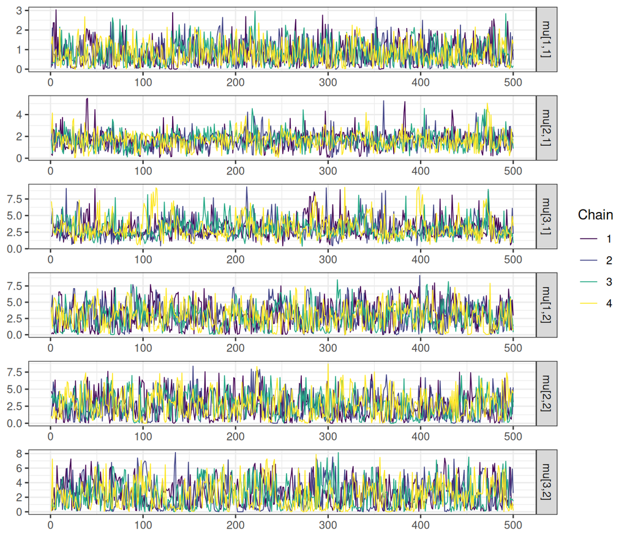

```r
mcmc_trace(output$draws(vars), pars = vars(starts_with("mu")),
           facet_args = list(ncol = 1, strip.position = "right"))
```

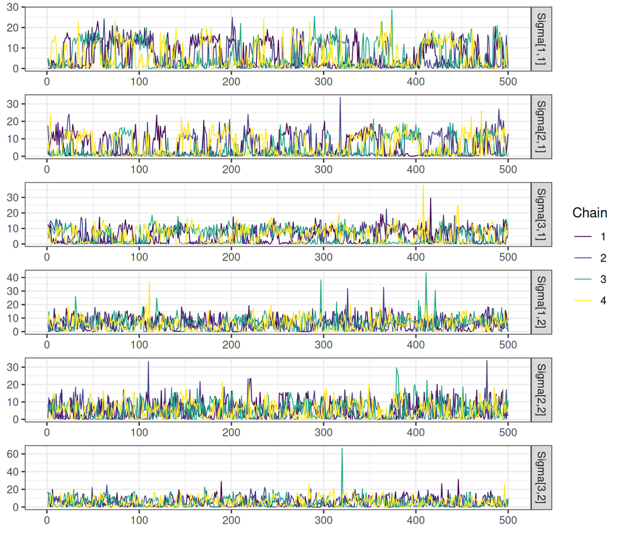

```r
mcmc_trace(output$draws(vars), pars = vars(starts_with("Sigma")),
           facet_args = list(ncol = 1, strip.position = "right"))
```

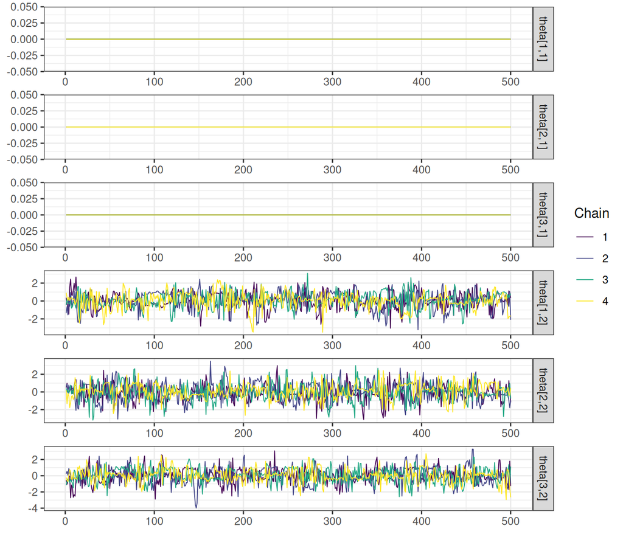

```r
mcmc_trace(output$draws(vars), pars = vars(starts_with("theta")),
           facet_args = list(ncol = 1, strip.position = "right"))
```

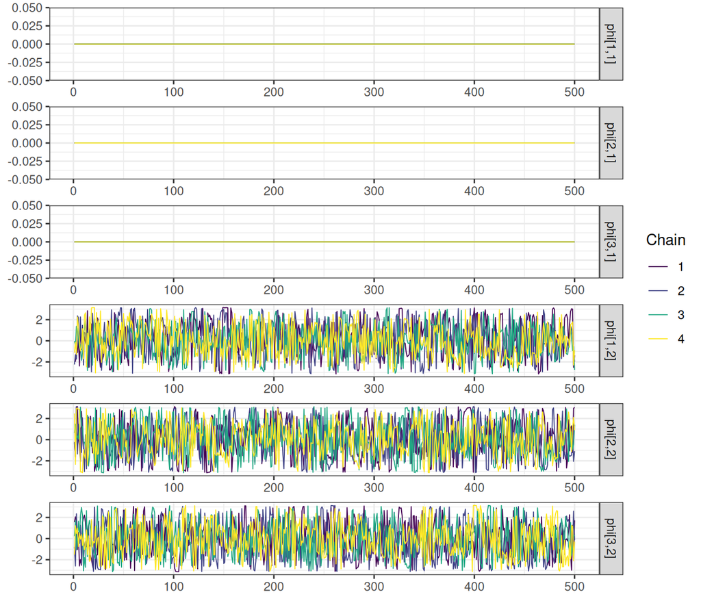

```r
mcmc_trace(output$draws(vars), pars = vars(starts_with("phi")),
           facet_args = list(ncol = 1, strip.position = "right"))
```

```r
valid_chains <- c(1:4)
output_draws <- output$draws(variables = vars, format = "df") |>
  subset_draws(chain = valid_chains)
output_draws_mat <- as.matrix(output_draws)

summary(output_draws)
```

```
# A tibble: 30 × 10
   variable  mean median    sd   mad     q5   q95  rhat ess_bulk ess_tail
   <chr>    <dbl>  <dbl> <dbl> <dbl>  <dbl> <dbl> <dbl>    <dbl>    <dbl>
 1 w[1,1]   0.392  0.313 0.251 0.179 0.125  0.876  1.01     462.     511.
 2 w[2,1]   0.434  0.335 0.312 0.220 0.118  1.02   1.01     521.     794.
 3 w[3,1]   0.352  0.240 0.303 0.139 0.0946 0.960  1.01     378.     617.
 4 w[1,2]   0.364  0.323 0.254 0.124 0.121  0.751  1.01     722.     510.
 5 w[2,2]   0.369  0.319 0.255 0.135 0.105  0.838  1.00     955.     873.
 6 w[3,2]   0.388  0.327 0.272 0.152 0.108  0.934  1.01     895.     788.
 7 mu[1,1]  0.803  0.675 0.594 0.615 0.0698 1.91   1.00    1072.     829.
 8 mu[2,1]  1.65   1.63  0.770 0.740 0.459  2.89   1.00    1028.    1295.
 9 mu[3,1]  3.07   2.71  1.50  1.18  1.19   6.07   1.00     569.     825.
10 mu[1,2]  2.88   2.74  1.88  2.17  0.240  6.24   1.01     659.     798.
# ℹ 20 more rows
```

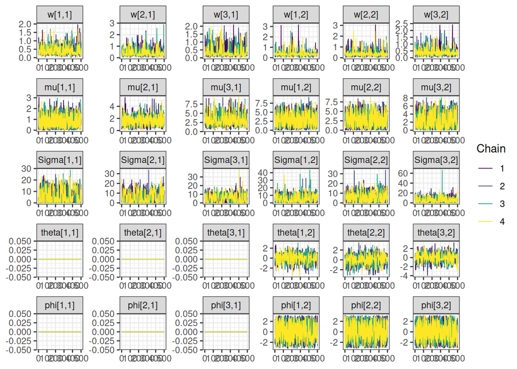

```r
mcmc_trace(output$draws(vars) |>
  subset_draws(chain = valid_chains))
```

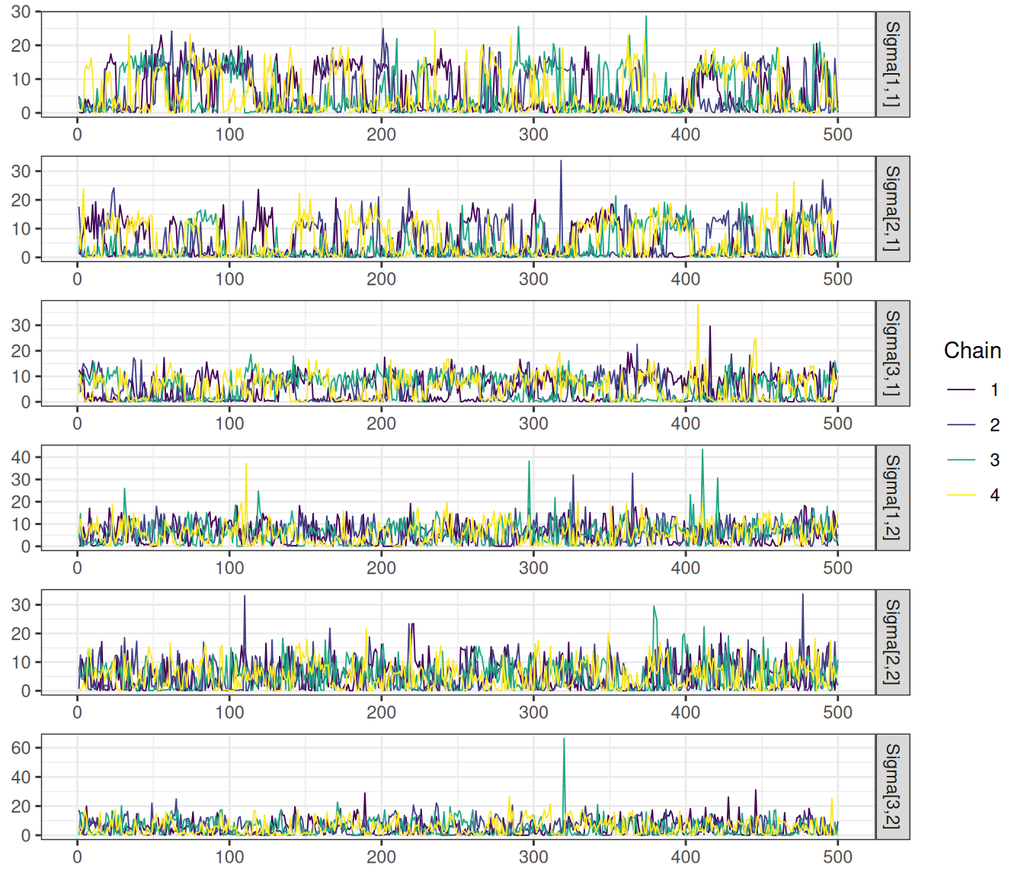

```r
mcmc_trace(output_draws, pars = vars(starts_with("Sigma")),
           facet_args = list(ncol = 1, strip.position = "right"))
```

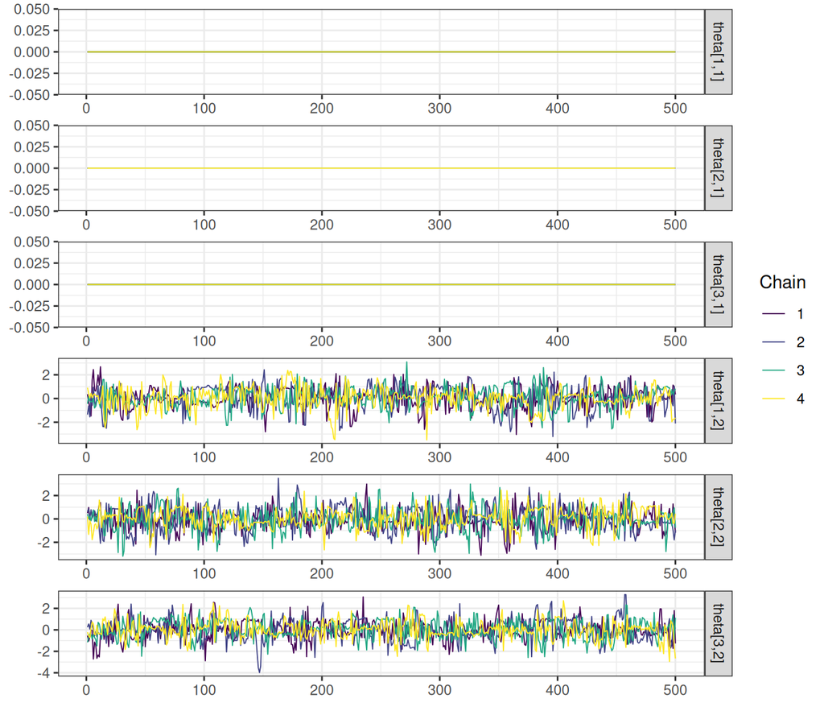

```r
mcmc_trace(output_draws, pars = vars(starts_with("theta")),
           facet_args = list(ncol = 1, strip.position = "right"))
```

## Posterior Predictive Check

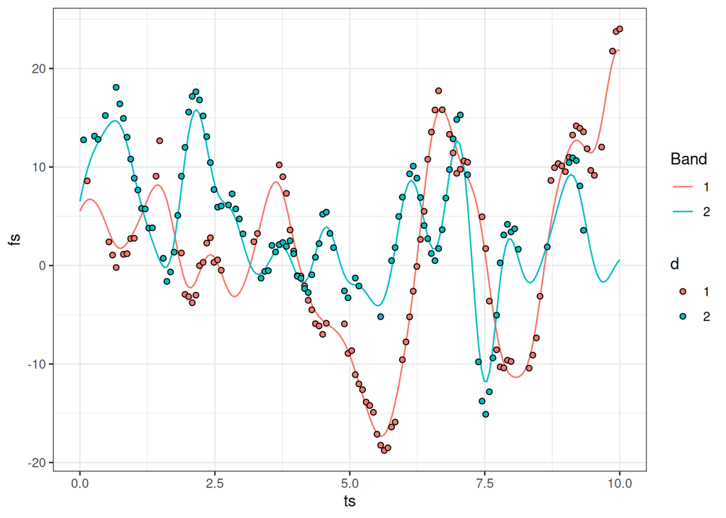

```r
n_star <- 200
ts1 <- seq(from = 0, to = 10, length.out = n_star)
ts2 <- ts1

# Draw posterior predictive samples using a particular posterior draw
post_draw <- as.data.frame(output_draws[sample.int(nrow(output_draws_mat), 1),])

pp_draw <- pred_D2_Q_draw(post_draw,
                          Q = Q,
                          t1 = band1_df$t, t2 = band2_df$t,
                          y1 = band1_df$y, y2 = band2_df$y,
                          y1_se = band1_df$y_se, y2_se = band2_df$y_se,
                          ts1 = ts1, ts2 = ts2)

ggplot() +
  geom_line(data = pp_draw, aes(x = ts, y = fs, colour = d)) +
  geom_point(data = input_df, aes(x = t, y = y, fill = d), shape = 21, size = 1.5) +
  labs(colour = "Band")
```

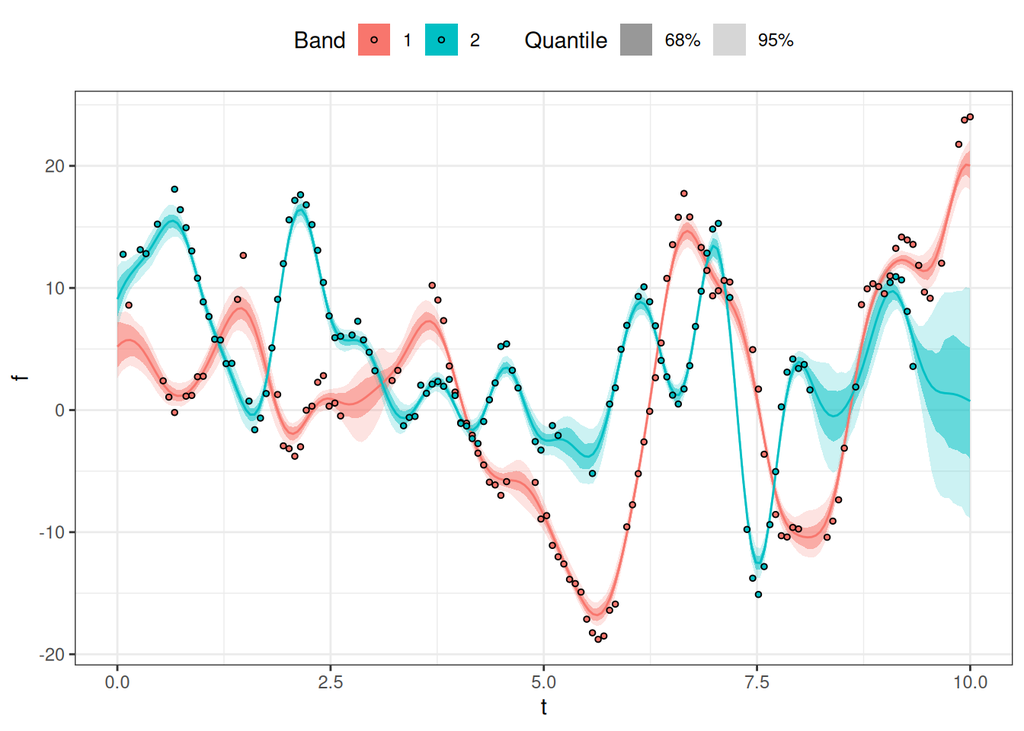

```r
pp_draws <- pred_D2_Q(draws = output_draws,
                      Q = Q,
                      t1 = band1_df$t,
                      t2 = band2_df$t,
                      y1 = band1_df$y,
                      y2 = band2_df$y,
                      y1_se = band1_df$y_se,
                      y2_se = band2_df$y_se,
                      ts1 = ts1,
                      ts2 = ts2,
                      n_draws = 100)

pp_draws |>
  summarise(.by = c(d, ts),
            Mean = mean(fs),
            Q2.5 = quantile(fs, probs = 0.025),
            Q97.5 = quantile(fs, probs = 0.975),
            Q16 = quantile(fs, probs = 0.16),
            Q84 = quantile(fs, probs = 0.84)) |>
  ggplot() +
  aes(x = ts, fill = d) +
  geom_ribbon(aes(ymin = Q2.5, ymax = Q97.5, alpha = "95%")) +
  geom_ribbon(aes(ymin = Q16, ymax = Q84, alpha = "68%")) +
  geom_line(aes(colour = d, y = Mean)) +
  geom_point(data = input_df, aes(x = t, y = y, fill = d), shape = 21, size = 1) +
  scale_alpha_manual(values = c(`95%` = 0.2, `68%` = 0.5)) +
  labs(colour = "Band", fill = "Band", y = "f", x = "t", alpha = "Quantile") +
  theme(legend.position = "top")
```

## Hyperparameter Posteriors

```r
print(input_params) # ground truth
```

```
$seed
[1] 2312

$w
     [,1] [,2]
[1,] 1.66 2.05
[2,] 2.20 1.49
[3,] 1.90 1.76

$mu
     [,1] [,2]
[1,] 0.07 0.47
[2,] 1.10 3.11
[3,] 1.12 0.12

$Sigma
        [,1]  [,2]
[1,]  0.4356  0.31
[2,] 10.4976 10.83
[3,] 13.6161 14.02

$theta
     [,1] [,2]
[1,]    0 2.32
[2,]    0 0.83
[3,]    0 0.10

$phi
     [,1]  [,2]
[1,]    0 -1.29
[2,]    0  0.33
[3,]    0  1.36
```

```r
posterior_means <- as.data.frame(output_draws) |>
  select(matches(vars), -.draw) |>
  colMeans()
posterior_means |> round(3)
```

```
    w[1,1]     w[2,1]     w[3,1]     w[1,2]     w[2,2]     w[3,2]    mu[1,1]
     0.392      0.434      0.352      0.364      0.369      0.388      0.803
   mu[2,1]    mu[3,1]    mu[1,2]    mu[2,2]    mu[3,2] Sigma[1,1] Sigma[2,1]
     1.650      3.068      2.876      2.529      2.344      6.035      4.958
Sigma[3,1] Sigma[1,2] Sigma[2,2] Sigma[3,2] theta[1,1] theta[2,1] theta[3,1]
     5.263      5.826      5.293      5.255      0.000      0.000      0.000
theta[1,2] theta[2,2] theta[3,2]   phi[1,1]   phi[2,1]   phi[3,1]   phi[1,2]
     0.040     -0.021      0.007      0.000      0.000      0.000      0.098
  phi[2,2]   phi[3,2]
     0.030     -0.070
```

```r
posterior_modes <- sapply(select(as.data.frame(output_draws), matches(vars), -.draw), estimate_mode)
posterior_modes
```

```
      w[1,1]       w[2,1]       w[3,1]       w[1,2]       w[2,2]       w[3,2]
 0.232752700  0.213381949  0.194459339  0.307435486  0.295848622  0.290381136
     mu[1,1]      mu[2,1]      mu[3,1]      mu[1,2]      mu[2,2]      mu[3,2]
 0.243300689  1.718581201  2.275940347  0.694100780  0.643523680  0.555326727
  Sigma[1,1]   Sigma[2,1]   Sigma[3,1]   Sigma[1,2]   Sigma[2,2]   Sigma[3,2]
 0.930788625  0.477990020  0.607714035  1.012864603  0.878213226  0.347514658
  theta[1,1]   theta[2,1]   theta[3,1]   theta[1,2]   theta[2,2]   theta[3,2]
-0.009371675 -0.009371675 -0.009371675  0.100958969 -0.164052786 -0.281167318
    phi[1,1]     phi[2,1]     phi[3,1]     phi[1,2]     phi[2,2]     phi[3,2]
-0.009371675 -0.009371675 -0.009371675  0.979966051  0.855253227  0.723497702
```

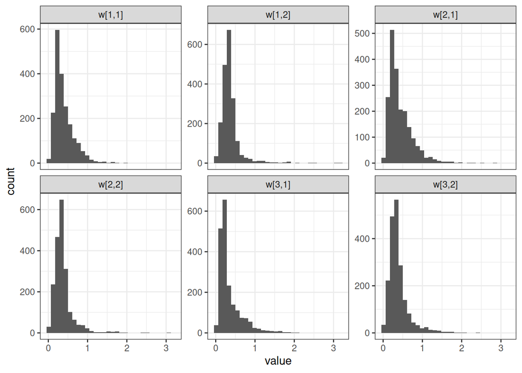

```r
output_draws |>
  as.data.frame() |>
  select(.draw, starts_with("w")) |>
  pivot_longer(2:7) |>
  drop_na(value) |>
  ggplot() +
  aes(x = value) +
  geom_histogram(bins = 30) +
  facet_wrap(vars(name), scales = "free_y")
```

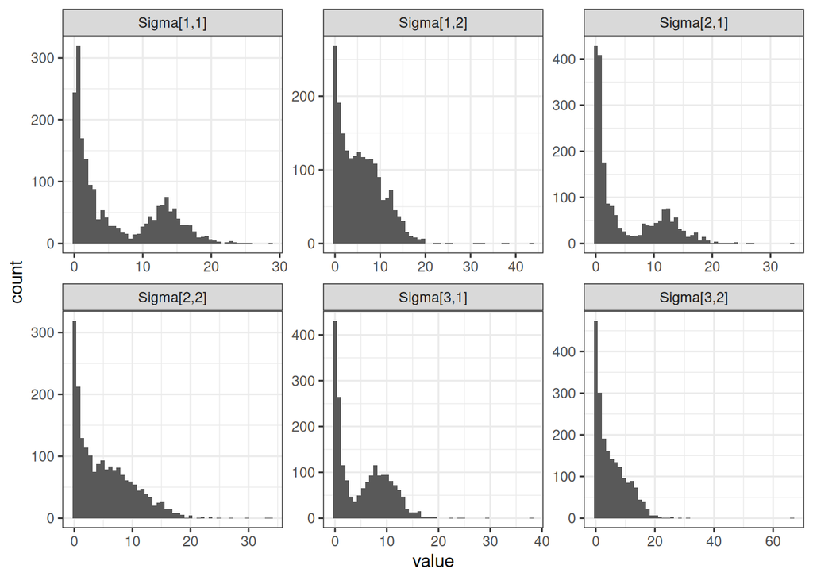

```r
output_draws |>
  as.data.frame() |>
  select(.draw, starts_with("Sigma")) |>
  pivot_longer(2:7) |>
  drop_na(value) |>
  ggplot() +
  aes(x = value) +
  geom_histogram(bins = 50) +
  facet_wrap(vars(name), scales = "free")
```

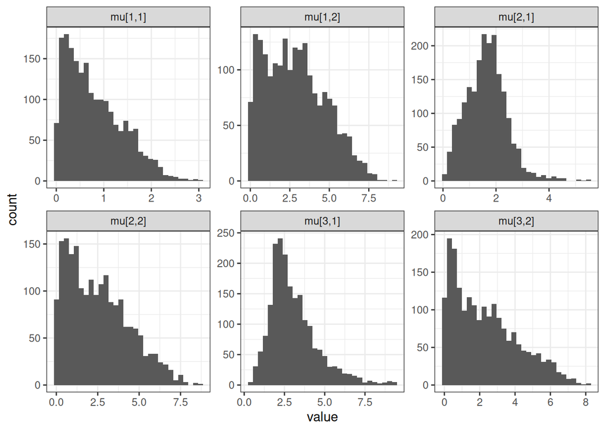

```r
output_draws |>
  as.data.frame() |>
  select(.draw, starts_with("mu")) |>
  pivot_longer(2:7) |>
  drop_na(value) |>
  ggplot() +
  aes(x = value) +
  geom_histogram(bins = 30) +
  facet_wrap(vars(name), scales = "free")
```

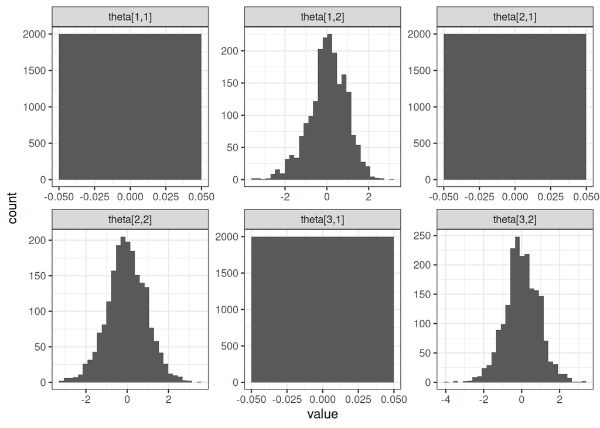

```r
output_draws |>
  as.data.frame() |>
  select(.draw, starts_with("theta")) |>
  pivot_longer(2:7) |>
  drop_na(value) |>
  ggplot() +
  aes(x = value) +
  geom_histogram(bins = 30) +
  facet_wrap(vars(name), scales = "free")
```

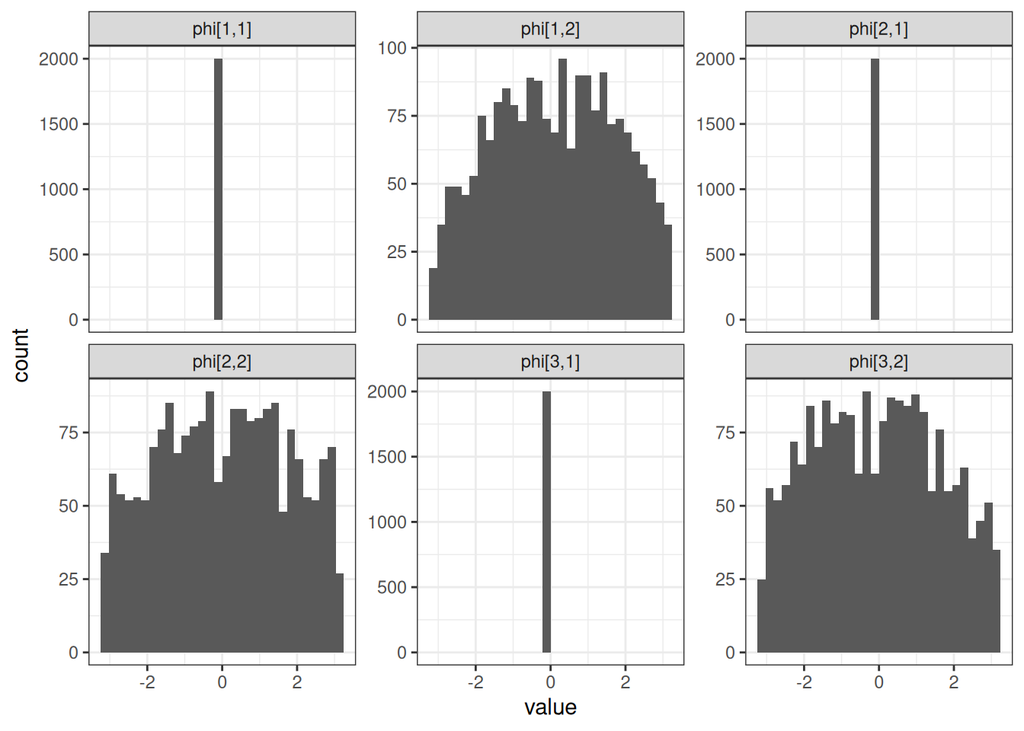

```r
output_draws |>
  as.data.frame() |>
  select(.draw, starts_with("phi")) |>
  pivot_longer(2:7) |>
  drop_na(value) |>
  ggplot() +
  aes(x = value) +
  geom_histogram(bins = 30) +
  facet_wrap(vars(name), scales = "free_y")
```

```r
input_params$theta
```

```
     [,1] [,2]
[1,]    0 2.32
[2,]    0 0.83
[3,]    0 0.10
```

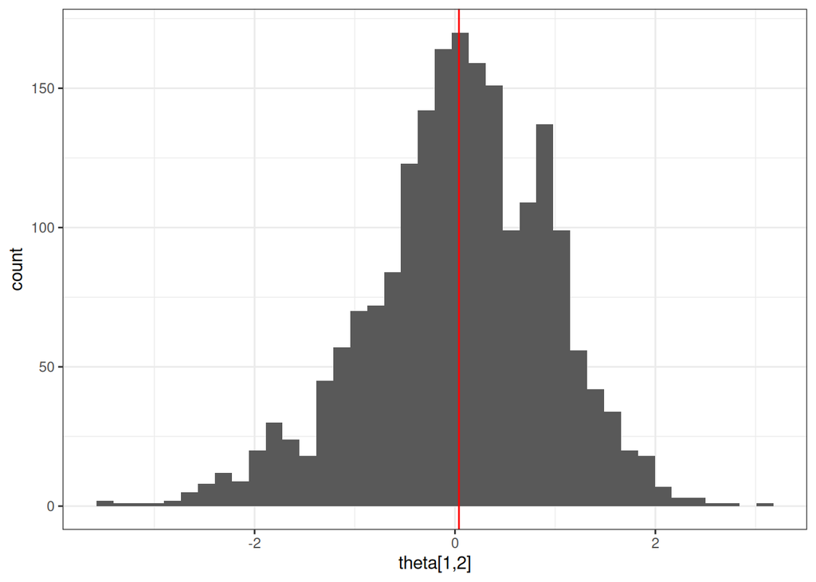

```r
output_draws |>
  ggplot() +
  aes(x = `theta[1,2]`) +
  geom_histogram(bins = 40) +
  geom_vline(xintercept = posterior_means["theta[1,2]"], colour = "red")
```

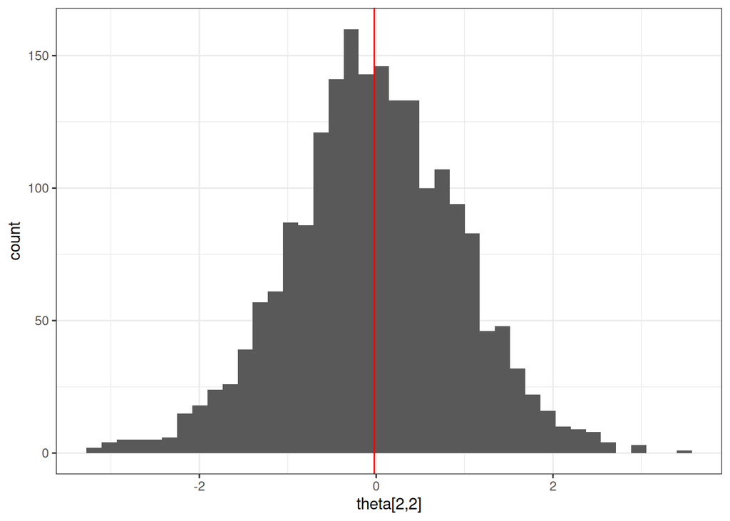

```r
output_draws |>
  ggplot() +
  aes(x = `theta[2,2]`) +
  geom_histogram(bins = 40) +
  geom_vline(xintercept = posterior_means["theta[2,2]"], colour = "red")
```

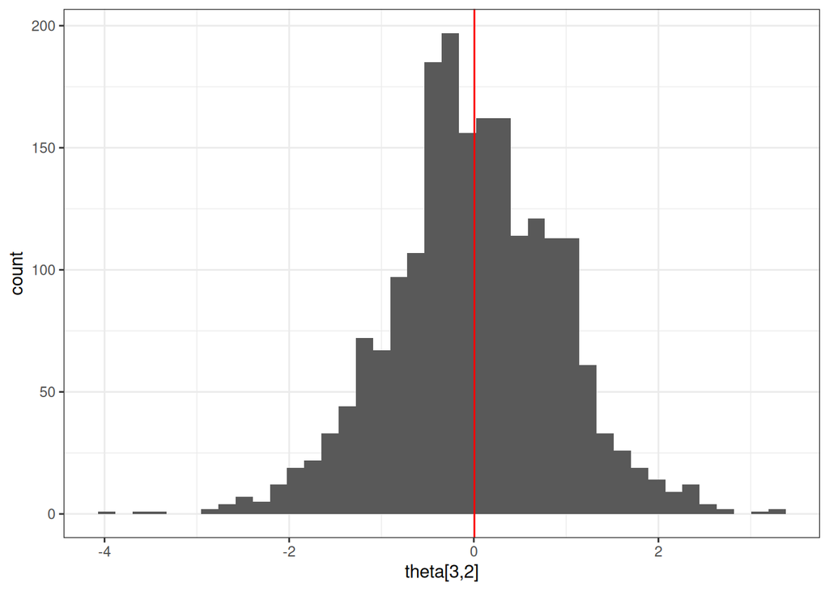

```r
output_draws |>
  ggplot() +
  aes(x = `theta[3,2]`) +
  geom_histogram(bins = 40) +
  geom_vline(xintercept = posterior_means["theta[3,2]"], colour = "red")
```

# Interpreting $\mu$s

```r
mus <- as.data.frame(output_draws) |>
  select(matches("mu"), -.draw) |>
  colMeans() |>
  matrix(ncol = 2)
mus
```

```
         [,1]     [,2]
[1,] 0.803410 2.875803
[2,] 1.650045 2.528855
[3,] 3.068105 2.344176
```

Each cell indicates the dominant oscillation frequency (radians/unit time) of the q-th (row) component in the i-th (column) band.

Where each mu differs between bands (in all components in this case), the cross-covariance has a frequency that is the variance weighted average of the two, i.e., $\mu_{ij}$ is frequency of the product of two Gaussians pulled towards the one with the narrower peak.

As the $\mu$s become more separated, the component is really two unrelated oscillators. In such cases, $\theta$ and $\phi$ are no longer meaningful and just reflect their priors.

# Interpreting $\theta$s

Entry theta[q, i] is band `i`’s (column) time shift within component `q` (row).

The delay between bands 1 and 2 in component q is `theta[q, 1] − theta[q, 2]`.

A delay is only meaningful relative to how fast the cross-covariance decays.

```r
thetas <- as.data.frame(output_draws) |>
  select(matches("theta"), -.draw) |>
  colMeans() |>
  matrix(ncol = 2)
thetas
```

```
     [,1]         [,2]
[1,]    0  0.039638346
[2,]    0 -0.021428427
[3,]    0  0.006533488
```

```r
phis <- as.data.frame(output_draws) |>
  select(matches("phi"), -.draw) |>
  colMeans() |>
  matrix(ncol = 2)
phis
```

```
     [,1]        [,2]
[1,]    0  0.09791734
[2,]    0  0.03028218
[3,]    0 -0.07009163
```

A time shift of $\theta$ corresponds to a phase shift of $\mu_{ij} \times \theta_{ij} + \phi_{ij}$ radians, i.e., the net phase offset at that frequency.

```r
mus * thetas + phis
```

```
     [,1]        [,2]
[1,]    0  0.21190943
[2,]    0 -0.02390720
[3,]    0 -0.05477598
```

# Interpreting $\Sigma$s

$\Sigma$s refer to the widths of the bumps in the spectral domain centred at the $\mu$s.

Coherence length is $\ell = \frac{1}{\sqrt{\Sigma}}$. There cannot be a stable cross-covariance, if two oscillators already drift out of phase within just one coherence length. Long coherence lengths (narrow spectral peaks) make the $\mu$ gap matter more, short coherence lengths (broad spectral peaks) make the gap matter less.

If cross-covariance is zero, then there’s insufficient information to estimate $\theta$ or $\phi$. $\mu$s are still identifiable but this component is really two unrelated oscillators, i.e., there is no shared signal to be delayed between bands.

```r
Sigmas <- as.data.frame(output_draws) |>
  select(matches("Sigma"), -.draw) |>
  colMeans() |>
  sqrt() |>
  matrix(ncol = 2)
Sigmas
```

```
         [,1]     [,2]
[1,] 2.456566 2.413658
[2,] 2.226727 2.300558
[3,] 2.294027 2.292482
```

# Interpreting $w$

```r
ws <- as.data.frame(output_draws) |>
  select(matches("w"), -.draw) |>
  colMeans() |>
  sqrt() |>
  matrix(ncol = 2)
ws
```

```
          [,1]      [,2]
[1,] 0.6262975 0.6032115
[2,] 0.6589071 0.6074704
[3,] 0.5935526 0.6231752
```

If $w$ was near zero (not in this case), then $\theta$ and $\phi$ for that component revert to their prior.